# Linear regression

data busteRs

season 2 / episode 16  
All rights reserved.  
Usage allowed only with the author's permission.  
Press `A` to turn slides into full text.  
Press `T` to show Table of Contents.

# Introduction

What do you think, is height hereditary?

Are the children of tall parents tall?

Probably yes, but I have a friend who is not tall, 165cm, but has a very tall child.

What portion of the child's height depends on the height of the parent?

We'll consider that question today.

We will look at a very known data set, which shows the dependence between the height of the parent and of the child.

We'll start by looking at how the dependence looks, then we'll answer the question of what portion of height is hereditary and finally try to estimate what will be the height of my children.

# Who was Francis Galton?

Basic mathematical linear data analysis methods were developed at the turn of the XVIII and XIX centuries. Those methods were initially used in navigation and astronomy.

The term "regression" was first used by Sir Francis Galton in the XIX century. Francis Galton was a renaissance man, active in anthropology, statistics, as well as many other sciences. In 1886 he published a work titled "Regression towards mediocrity in hereditary stature’" in The Journal of the Anthropological Institute of Great Britain and Ireland, in which he presented the results of studies on the heredity of height. Galton observed that the sons of tall fathers are very on average taller than sons of short fathers, but their average height is lower than the average height of fathers. Similarly, height of sons of short fathers is closer to the average in the population. He called that phenomenon *regression toward the mean*. Galton proposed an equation describing the dependence between the height of sons and fathers or equivalently describing the height regression from generation to generation in the direction of the average value (today we would call this equation a regression equation).

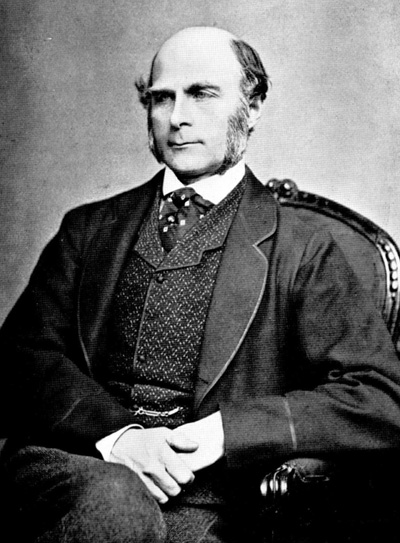

# Does height of the parents matter?

Our adventure with linear regression will also start with the data collected by Galton. The data set is called `galton`, we'll see a couple of initial observations from this set.

```r
# w tym pakiecie znajduje się zbiór danych galton
library(PogromcyDanych)
# pierwsze 6 wierszy
head(galton)
```

```
##     syn rodzic
## 1 156.7  179.1
## 2 156.7  174.0
## 3 156.7  166.4
## 4 156.7  163.8
## 5 156.7  162.6
## 6 158.0  171.4
```

The `rodzic` column presents a weighted mean value of height of the parents (average height of the father and 1.08 of height of the mother), and the `syn` column presents height of adult son. Heights are provided in centimeters.

# Does height of the parents matter?

The question that interested Galton, and we are interested in, is whether there is a dependence between the height of the parents and of the child.

Modeling always begins with a plot, so let's see how that dependence between height of the child and of the parent looks like graphically.

To present this dependence we use the `ggplot2` packet and the `ggplot()` function. For more information on how to use this function refer to the first four episodes of this season (dedicated to visualization).

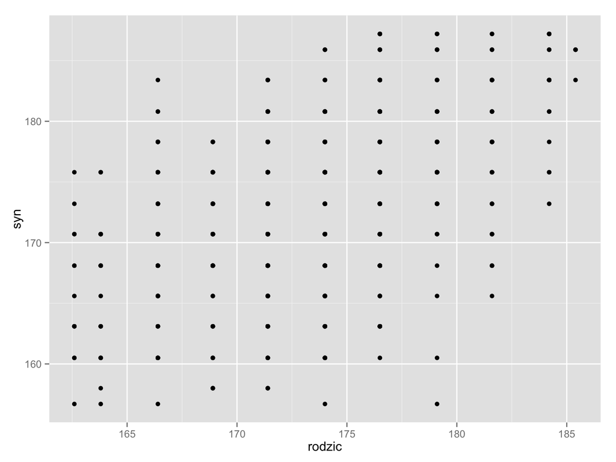

```r
ggplot(galton, aes(x=rodzic, y=syn)) +
  geom_point()
```

# Little is seen without the noise

As the data is collected with an accuracy of half an inch, the points for different rows overlap. One dot can mean many parent's height x child's height pairs.

Observing such data (collected with small precision), for the presentation it is worth a disturb it with a little noise injection. We'll use the `position = "jitter"` argument.

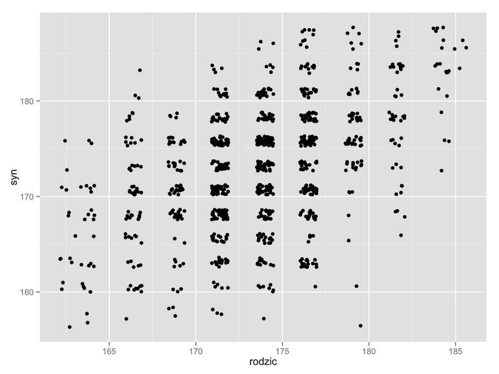

```r
ggplot(galton, aes(x=rodzic, y=syn)) +
  geom_point(position = "jitter")
```

# What is the dependence?

It seems there is a dependence, but what is it? One possibility is to compute the average height of the child for each group of average height of parents.

Using the `%>%` operator (more broadly discussed in the first season), the average height of the child for each group of heights of the parents is determined as follows.

```r
srednie <- galton %>%
  group_by(rodzic) %>%
  summarise(srednia = mean(syn))
# wyświetl te średnie
srednie
```

```
## Source: local data frame [11 x 2]
##
##    rodzic  srednia
## 1   162.6 165.8786
## 2   163.8 166.1000
## 3   166.4 169.4273
## 4   168.9 170.3231
## 5   171.4 171.6692
## 6   174.0 172.7639
## 7   176.5 174.5082
## 8   179.1 176.7721
## 9   181.6 178.0070
## 10  184.2 182.5842
## 11  185.4 185.2750
```

# What is the dependence?

Let's draw in blue color a vector of mean values in "height groups of parents", in the background we'll display all the cases from the data set.

Perfect! We see that on average the taller the parents the taller the children.

However, using the same mean values is quite uncomfortable. To describe this dependence, the mean value for every height of the parent must be remembered. Moreover, the mean values in groups of very tall or very short parents are determined on the basis of only a few observations, and so are determined inaccurately.

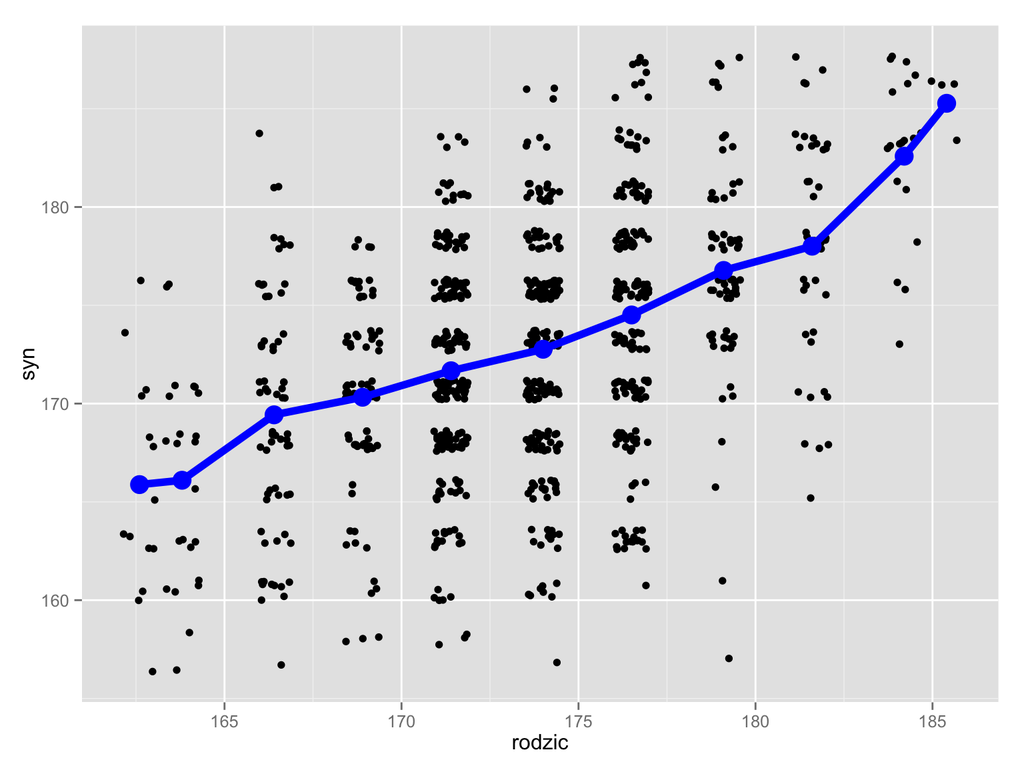

```r
ggplot(galton, aes(x=rodzic, y=syn)) +
  geom_point(position = "jitter") +
# poniższa funkcja dorysowuje średnie w grupach
  geom_line(data=srednie, aes(x=rodzic, y=srednia), size=2, color = "blue") +
  geom_point(data=srednie, aes(x=rodzic, y=srednia), size=5, color = "blue")
```

# Linear model

It would be more convenient to describe dependence between the height of the parent and the average height of the child using fewer parameters, than remembering the average height of children for each possible height of the parent.

Let's assume that we can describe this dependence with a linear dependence, as follows

$średni.wzrost.dziecka = b_0 + średni.wzrost.rodziców * b_1$

where $b_0$ and $b_1$ are certain unknown values.

# Assessment of factors

Process of determining unknown values on the basis of the model and the data is called estimation.

In the R program, we can use the `lm()` (acronym of *linear model*) function for estimation.

For the $średni.wzrost.dziecka = b_0 + średni.wzrost.rodziców * b_1$ model

or using the names of the variables in our data set $syn = b_0 + rodzic * b_1$

The function estimating the parameters looks as follows.

```r
lm(syn ~ 1 + rodzic, data = galton)
```

```
##
## Call:
## lm(formula = syn ~ 1 + rodzic, data = galton)
##
## Coefficients:
## (Intercept)       rodzic
##     60.8130       0.6463
```

```r
# osoby lubiące parametr %>% mogą też napisać
# galton %>% lm(syn ~ 1 + rodzic, data = .)
```

`lm()` function assumes two arguments, the first is a formula describing the assumed model, and the second argument indicates the data set.

The formula consists of the left and the right side, separated with a `~` symbol. The left side describes the variable we want to describe, so called dependent variable, and the right side is composed of variables that we use to describe the left, so called independent variables. The `1 + parent` note means that we want to describe the average height of a child with a formula $1 * b_0 + parent * b_1$, in which we have to determine $b_0$ and $b_1$.

# Assessment of factors

The result of `lm()` function is a detailed description of adjusted model. If we are only interested in assessments $b_0$ and $b_1$, we can refer to those assessments using the `coef()` function.

```r
modelSynRodzic <- lm(syn ~ 1 + rodzic, data=galton)
coef(modelSynRodzic)
```

```
## (Intercept)      rodzic
##   60.812990    0.646291
```

Thus we get a model

*średni.wzrost.dziecka = 60.813 + wzrost.rodzica * 0.6463*

We can skip the `1+` term in the formula, it is added to the formula by default, so we get the same result using the following instructions.

```r
# wartość 1 dodawana jest automatycznie
modelSynRodzic <- lm(syn ~ rodzic, data=galton)
coef(modelSynRodzic)
```

```
## (Intercept)      rodzic
##   60.812990    0.646291
```

# How does dependence between height of the child and of the parent look like

In the above reasoning we considered several alternative models. Let's summarize them here.

1. A model in which average height of the child equals height of the parent, $średni.wzrost.dziecka = wzrost.rodziców$
2. A model, in which there is no dependence between the height of parents and of children, thus for each height of parents, the average height of children is the same, $średni.wzrost.dziecka = b_0$
3. A model in which average height of the child is linearly dependent on the height of the parents $średni.wzrost.dziecka = b_0 + wzrost.rodziców * b_1$
4. A model in which average height of a child is different for each height of a parent.

Those models were ordered according to the number of unknown parameters. The first of these models has no parameter, another has one parameter, the next has two, and the last has 11 parameters.

Let's show how each of these four models looks like against data. Meaning of colors: the first model is gold, the second - black, the third - red, the fourth - blue.

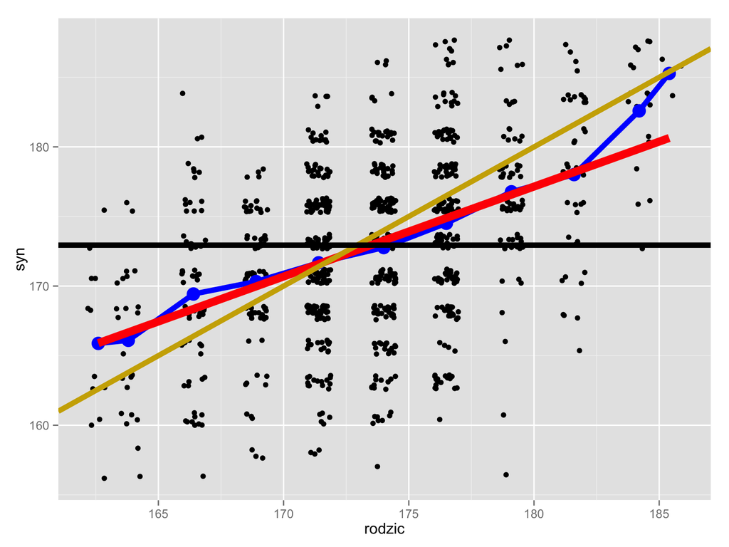

```r
ggplot(galton, aes(x=rodzic, y=syn)) +
  geom_point(position = "jitter")+
  # model 4, dla każdej grupy wzrostu rodziców wyznaczamy średni wzrost dzieci
  geom_line(data=srednie, aes(x=rodzic, y=srednia), size=2, color = "blue") +
  geom_point(data=srednie, aes(x=rodzic, y=srednia), size=5, color = "blue")  +
  # model 3, do danych dopasowujemy trend liniowy
  geom_smooth(method="lm", se=FALSE, size=3, color="red") +
  # model 2, wzost dziecka jest taki jak wzrost rodzica
  geom_abline(size=2, color="gold3")+
  # model 1, wzrost dziecka nei zależy od wzrostu rodzica
  geom_abline(size=2, slope=0, intercept=mean(galton$syn))
```

# Which model to choose?

The height dependence between a child and a parent may be described on different models. Which one to choose?

On the one hand too simple models (1 and 2) do not describe the data well, the plot below shows that there is a systematic problem within them.

On the other hand, too complex models (4) make it difficult for us to understand the whole relationship. So what if we have an average of children for parents with height of 170 and 172 cm, since this knowledge cannot be extended to the parents with height of 171 cm?

Working with the modeling is selecting a model that fits the data well, but not too well. Often (not always) the linear model works.

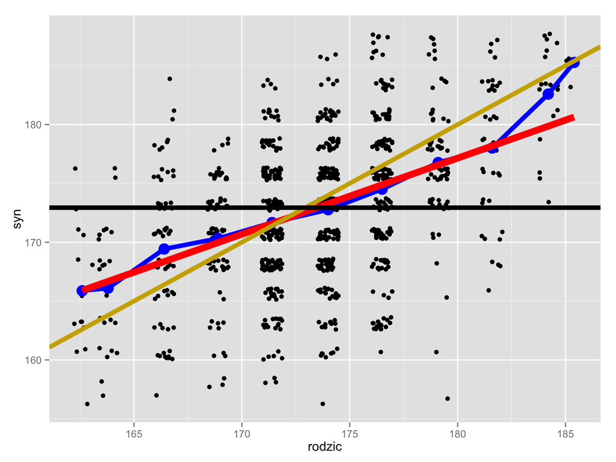

# Tasks

- For each height of a parent from the `galton` data set, determine the mean value of how much shorter are the children compared to the parents.
- With determined parameters of *b0* and *b1* calculate assessments of average height of a child for each average height of a parent.
- Determine the differences between the assessments of the linear model and the mean values calculated separately for each group of parents
- In the `PogromcyDanych` packet we have also included `pearson` data set gathered by Pearson. In this data set heights of fathers and sons were collected.

For this data set, determine the linear regression model and draw a data set with a linear regression curve.

Do the linear regression parameters in Pearson data set (with father's height) differ from the parameters in Galton data set (with average height of parents)?